# Tercera entrega — Clasificación con las guías OMS 2021

Calidad del aire en CABA · UTN FRC · Grupo 12

Continúa `tercera_entrega_modelado.ipynb`. Con los cortes EPA casi todos los días son *Buena* y el clasificador alcanza una accuracy alta sin detectar episodios. Aquí se reemplaza la etiqueta por las guías OMS 2021 (promedios de 24 h), se justifican los parámetros con una grilla en validación y se interpretan los modelos. Las celdas leen resultados persistidos por `.\run.ps1 classify-oms`.

```python
from pathlib import Path
import json
import pandas as pd
from IPython.display import display, Image, Markdown
ROOT = Path.cwd().parent if Path.cwd().name == "notebooks" else Path.cwd()
OUT = ROOT / "outputs/clasificacion_oms"
report = json.loads((OUT / "reporte.json").read_text(encoding="utf-8"))
metrics = pd.read_csv(OUT / "metricas_clasificacion.csv")
detail = pd.read_csv(OUT / "metricas_por_clase.csv")
trials = pd.read_csv(OUT / "candidatos_validacion.csv")
pd.set_option("display.max_columns", 20)
print("Cobertura diaria:", json.dumps(report["coverage"], indent=1))
```

```
Cobertura diaria: {
 "CO": {
  "station_days_available": 17108,
  "eligible_station_days": 13599,
  "excluded_station_days": 3509,
  "eligible_without_previous_day": 655
 },
 "NO2": {
  "station_days_available": 17108,
  "eligible_station_days": 13418,
  "excluded_station_days": 3690,
  "eligible_without_previous_day": 540
 },
 "PM10": {
  "station_days_available": 17108,
  "eligible_station_days": 13311,
  "excluded_station_days": 3797,
  "eligible_without_previous_day": 634
 }
}
```

## 1. Por qué cambiar de estándar

| Contaminante | Guía OMS 2021 (24 h) | Objetivo intermedio usado | EPA (alto) |
| --- | --- | --- | --- |
| NO₂ | 25 µg/m³ (≈13 ppb) | 50 µg/m³ (OI-2) | ≥101 ppb |
| PM10 | 45 µg/m³ | — | ≥155 µg/m³ |
| CO | 4 mg/m³ (≈3,5 ppm) | — | ≥9,5 ppm |

Los cortes EPA están pensados para episodios severos; en CABA casi no ocurren con estos contaminantes. La OMS fija valores basados en efectos en la salud a exposiciones más bajas. La etiqueta pasa a responder una pregunta útil: *¿el aire de esta estación cumple hoy la guía sanitaria?*

| pollutant | split category | purga | test | train | validation |
| --- | --- | --- | --- | --- | --- |
| CO | Cumple guía OMS | 10.0 | 1679.0 | 11109.0 | 801.0 |
|  | Supera guía OMS | 0.0 | 0.0 | 0.0 | 0.0 |
| NO2 | Cumple guía OMS | 7.0 | 372.0 | 2457.0 | 87.0 |
|  | Entre guía y objetivo intermedio | 3.0 | 970.0 | 6277.0 | 346.0 |
|  | Supera objetivo intermedio | 0.0 | 322.0 | 2329.0 | 248.0 |
| PM10 | Cumple guía OMS | 8.0 | 1488.0 | 10147.0 | 854.0 |
|  | Supera guía OMS | 0.0 | 48.0 | 734.0 | 32.0 |

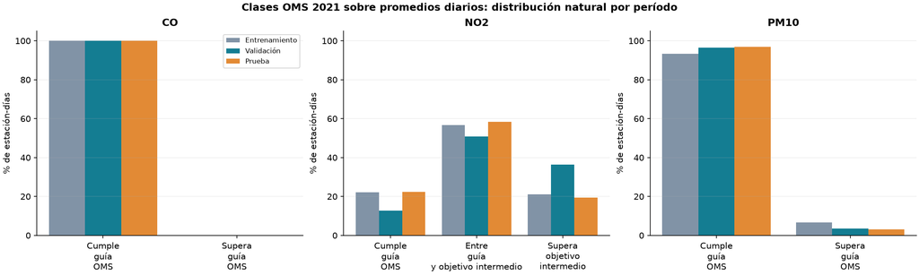

```python
dist = pd.read_csv(OUT / "distribucion_categorias.csv")
display(dist.query("station == 'todas'").pivot_table(index=["pollutant","category"], columns="split", values="count", fill_value=0))
display(Image(filename=str(OUT / "figuras/distribucion_oms.png")))
```

NO₂ queda con tres clases de tamaño comparable y PM10 con una excedencia minoritaria pero evaluable (decenas de días en prueba, cientos en entrenamiento). CO no supera la guía ningún día: no se clasifica.

## 2. Algoritmos, parámetros y selección

Se mantienen la partición temporal, las entradas diarias y las métricas del modelado original. Se comparan una referencia (clase mayoritaria de entrenamiento), Random Forest y XGBoost. Justificación de la grilla:

- **Random Forest**: 300 árboles (el error se estabiliza; más árboles sólo agregan tiempo), `max_features=0.8` como en el modelado original; se prueba profundidad 8, 12 o sin límite y `min_samples_leaf` 5 o 20 para controlar el sobreajuste con ~11.000 estación-días.
- **XGBoost**: tasa de aprendizaje 0,05 con 300 o 600 árboles (aprendizaje lento, más estable); profundidad 3, 4 o 6 para variar las interacciones permitidas; `subsample` y `colsample_bytree` 0,8 y `reg_lambda=5` como regularización, igual que el modelado original.
- **Ponderación de clases**: exponente 0 (sin pesos), 0,5 (suave) o 1 (balanceado), calculado sólo con entrenamiento. No se remuestrea ni se balancean validación y prueba.
- **Entradas**: `meteo` (meteorología y calendario) o `rezago` (además, el promedio del día anterior).

Se elige por F1 macro de validación (2024) y la elección se guarda antes de evaluar la prueba.

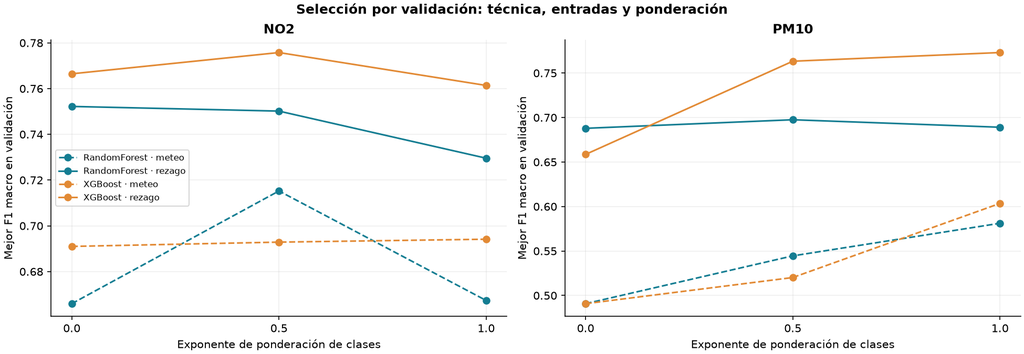

|  | elegido | F1 macro validación |
| --- | --- | --- |
| NO2 | XGBoost_rezago | 0.7758 |
| PM10 | XGBoost_rezago | 0.7731 |

```
NO2 — 10 mejores ensayos de validación
```

|  | model | feature_set | weight_power | max_depth | min_samples_leaf | n_estimators | validation_f1_macro | validation_balanced_accuracy |
| --- | --- | --- | --- | --- | --- | --- | --- | --- |
| 70 | XGBoost | rezago | 0.5 | 6.0 | NaN | 600 | 0.775768 | 0.770199 |
| 69 | XGBoost | rezago | 0.0 | 6.0 | NaN | 600 | 0.766468 | 0.752971 |
| 67 | XGBoost | rezago | 0.5 | 6.0 | NaN | 300 | 0.762047 | 0.761888 |
| 64 | XGBoost | rezago | 0.5 | 4.0 | NaN | 600 | 0.762015 | 0.764935 |
| 68 | XGBoost | rezago | 1.0 | 6.0 | NaN | 300 | 0.761383 | 0.769684 |
| 71 | XGBoost | rezago | 1.0 | 6.0 | NaN | 600 | 0.761063 | 0.765494 |
| 63 | XGBoost | rezago | 0.0 | 4.0 | NaN | 600 | 0.760394 | 0.748355 |
| 57 | XGBoost | rezago | 0.0 | 3.0 | NaN | 600 | 0.759885 | 0.746990 |
| 65 | XGBoost | rezago | 1.0 | 4.0 | NaN | 600 | 0.757715 | 0.775957 |
| 66 | XGBoost | rezago | 0.0 | 6.0 | NaN | 300 | 0.756392 | 0.741074 |

```
PM10 — 10 mejores ensayos de validación
```

|  | model | feature_set | weight_power | max_depth | min_samples_leaf | n_estimators | validation_f1_macro | validation_balanced_accuracy |
| --- | --- | --- | --- | --- | --- | --- | --- | --- |
| 140 | XGBoost | rezago | 1.0 | 6.0 | NaN | 300 | 0.773053 | 0.773053 |
| 133 | XGBoost | rezago | 0.5 | 4.0 | NaN | 300 | 0.763306 | 0.743560 |
| 127 | XGBoost | rezago | 0.5 | 3.0 | NaN | 300 | 0.761357 | 0.757428 |
| 137 | XGBoost | rezago | 1.0 | 4.0 | NaN | 600 | 0.759566 | 0.771297 |
| 130 | XGBoost | rezago | 0.5 | 3.0 | NaN | 600 | 0.755286 | 0.728520 |
| 131 | XGBoost | rezago | 1.0 | 3.0 | NaN | 600 | 0.704611 | 0.789666 |
| 134 | XGBoost | rezago | 1.0 | 4.0 | NaN | 300 | 0.698332 | 0.774627 |
| 118 | RandomForest | rezago | 0.5 | 12.0 | 20.0 | 300 | 0.697518 | 0.706455 |
| 139 | XGBoost | rezago | 0.5 | 6.0 | NaN | 300 | 0.695666 | 0.652152 |
| 112 | RandomForest | rezago | 0.5 | 8.0 | 20.0 | 300 | 0.694145 | 0.705869 |

```python
display(Image(filename=str(OUT / "figuras/seleccion_validacion.png")))
display(pd.DataFrame({p: {"elegido": s["selected"], "F1 macro validación": round(s["validation_score"], 4)} for p, s in report["selections"].items()}).T)
cols = ["model","feature_set","weight_power","max_depth","min_samples_leaf","n_estimators","validation_f1_macro","validation_balanced_accuracy"]
for p in report["config"]["pollutants"]:
    print(p, "— 10 mejores ensayos de validación")
    display(trials.query("pollutant == @p").sort_values("validation_f1_macro", ascending=False)[cols].head(10))
```

## 3. Evaluación en prueba (2025–2026)

Matriz de confusión, accuracy, precision, recall, F1 y tasa de falsos positivos (FPR = FP / (FP + TN) por clase frente al resto). La referencia mayoritaria muestra cuánto de la accuracy se explica sólo por el desbalance.

|  | pollutant | model | n | accuracy | precision_macro | recall_macro | f1_macro | balanced_accuracy | false_positive_rate_macro |
| --- | --- | --- | --- | --- | --- | --- | --- | --- | --- |
| 4 | NO2 | Mayoria_train | 1664 | 0.582933 | 0.194311 | 0.333333 | 0.245507 | 0.333333 | 0.333333 |
| 12 | NO2 | RandomForest_meteo | 1664 | 0.665865 | 0.711553 | 0.629485 | 0.607157 | 0.629485 | 0.206635 |
| 20 | NO2 | XGBoost_meteo | 1664 | 0.638221 | 0.701725 | 0.605948 | 0.573600 | 0.605948 | 0.223356 |
| 28 | NO2 | RandomForest_rezago | 1664 | 0.750601 | 0.744727 | 0.698046 | 0.717034 | 0.698046 | 0.164603 |
| 36 | NO2 | XGBoost_rezago | 1664 | 0.768029 | 0.769117 | 0.727396 | 0.734811 | 0.727396 | 0.151488 |
| 44 | PM10 | Mayoria_train | 1536 | 0.968750 | 0.484375 | 0.500000 | 0.492063 | 0.500000 | 0.500000 |
| 52 | PM10 | RandomForest_meteo | 1536 | 0.885417 | 0.538372 | 0.618280 | 0.546197 | 0.618280 | 0.381720 |
| 60 | PM10 | XGBoost_meteo | 1536 | 0.879557 | 0.535633 | 0.615255 | 0.541333 | 0.615255 | 0.384745 |
| 68 | PM10 | RandomForest_rezago | 1536 | 0.946615 | 0.596477 | 0.619624 | 0.606538 | 0.619624 | 0.380376 |
| 76 | PM10 | XGBoost_rezago | 1536 | 0.947266 | 0.598321 | 0.619960 | 0.607836 | 0.619960 | 0.380040 |

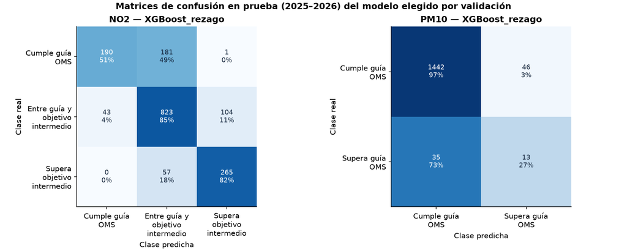

|  | pollutant | model | category | support | precision | recall | f1 | false_positive_rate | tp | fp | fn | tn |
| --- | --- | --- | --- | --- | --- | --- | --- | --- | --- | --- | --- | --- |
| 108 | NO2 | XGBoost_rezago | Cumple guía OMS | 372 | 0.815451 | 0.510753 | 0.628099 | 0.033282 | 190 | 43 | 182 | 1249 |
| 109 | NO2 | XGBoost_rezago | Entre guía y objetivo intermedio | 970 | 0.775683 | 0.848454 | 0.810438 | 0.342939 | 823 | 238 | 147 | 456 |
| 110 | NO2 | XGBoost_rezago | Supera objetivo intermedio | 322 | 0.716216 | 0.822981 | 0.765896 | 0.078241 | 265 | 105 | 57 | 1237 |
| 192 | PM10 | XGBoost_rezago | Cumple guía OMS | 1488 | 0.976303 | 0.969086 | 0.972681 | 0.729167 | 1442 | 35 | 46 | 13 |
| 193 | PM10 | XGBoost_rezago | Supera guía OMS | 48 | 0.220339 | 0.270833 | 0.242991 | 0.030914 | 13 | 46 | 35 | 1442 |

|  | pollutant | model | station | n | accuracy | f1_macro | balanced_accuracy |
| --- | --- | --- | --- | --- | --- | --- | --- |
| 37 | NO2 | XGBoost_rezago | centenario | 571 | 0.746060 | 0.606858 | 0.691573 |
| 38 | NO2 | XGBoost_rezago | cordoba | 542 | 0.778598 | 0.673760 | 0.688489 |
| 39 | NO2 | XGBoost_rezago | la_boca | 551 | 0.780399 | 0.714009 | 0.726393 |
| 77 | PM10 | XGBoost_rezago | centenario | 541 | 0.966728 | 0.582419 | 0.590584 |
| 78 | PM10 | XGBoost_rezago | cordoba | 510 | 0.945098 | 0.519192 | 0.518092 |
| 79 | PM10 | XGBoost_rezago | la_boca | 485 | 0.927835 | 0.662692 | 0.702435 |

```python
cols = ["pollutant","model","n","accuracy","precision_macro","recall_macro","f1_macro","balanced_accuracy","false_positive_rate_macro"]
display(metrics.query("split == 'test' and station == 'todas'")[cols])
display(Image(filename=str(OUT / "figuras/matrices_oms.png")))
display(detail.query("split == 'test' and station == 'todas' and selected_by_validation")[["pollutant","model","category","support","precision","recall","f1","false_positive_rate","tp","fp","fn","tn"]])
display(metrics.query("split == 'test' and station != 'todas' and selected_by_validation")[["pollutant","model","station","n","accuracy","f1_macro","balanced_accuracy"]])
```

## 4. Patrones e interpretación

TreeSHAP descompone cada predicción en contribuciones de las variables (en log-odds). Se agrupan las columnas one-hot y los resúmenes diarios de una misma variable. Son asociaciones aprendidas por el modelo, no causas.

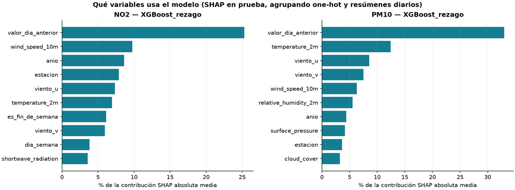

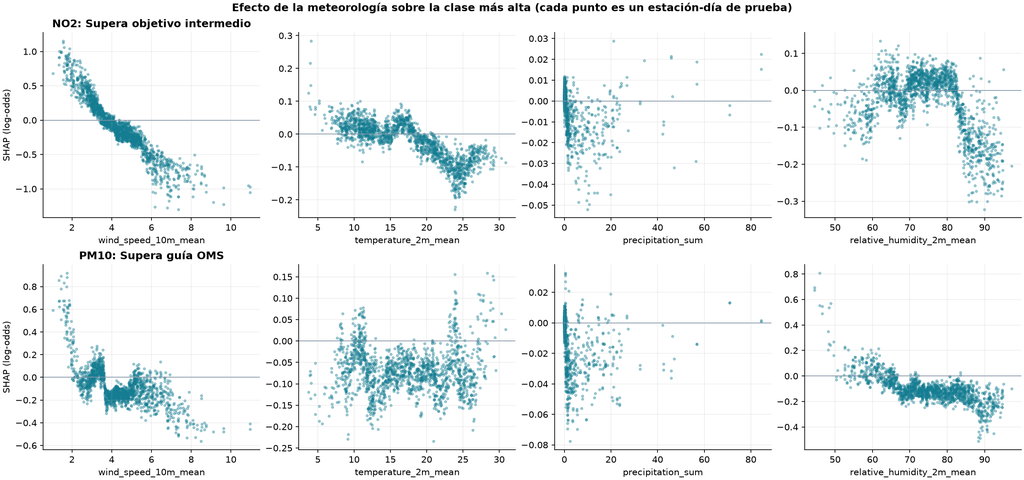

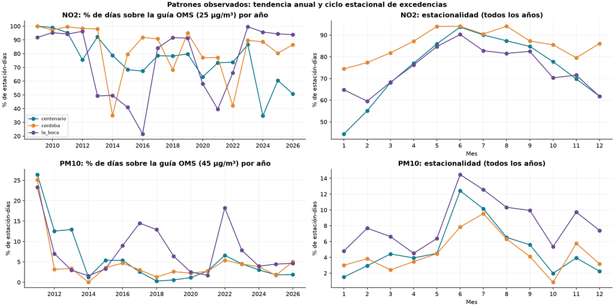

```python
display(Image(filename=str(OUT / "figuras/shap_importancia.png")))
display(Image(filename=str(OUT / "figuras/shap_dependencia.png")))
display(Image(filename=str(OUT / "figuras/patrones_excedencias.png")))
```

```python
display(Markdown((OUT / "resumen_oms.md").read_text(encoding="utf-8").split("## Método")[0]))
```

Clasificación diaria con las guías OMS 2021

Estación-día, NO₂ y PM10. CO se describe.

- NO2: validación eligió XGBoost_rezago. En prueba, F1 macro 0.735 frente a 0.246 de la clase mayoritaria; balanced accuracy 72.7% y accuracy 76.8%. Variables más usadas (SHAP): valor_dia_anterior (25%), wind_speed_10m (10%), anio (9%), estacion (8%).

- PM10: validación eligió XGBoost_rezago. En prueba, F1 macro 0.608 frente a 0.492 de la clase mayoritaria; balanced accuracy 62.0% y accuracy 94.7%. Variables más usadas (SHAP): valor_dia_anterior (33%), temperature_2m (12%), viento_u (9%), viento_v (7%).

- CO: 0 estación-días superan la guía OMS de 4 mg/m³ en todo el período; con una sola clase no hay problema de clasificación y CO se analiza sólo con la regresión de la entrega.

## 5. Reproducibilidad

`.\run.ps1 classify-oms` reentrena la grilla y regenera métricas, figuras, modelos y este notebook. Configuración: `config/clasificacion_oms.json` (grilla) y `config/indices_oms.json` (cortes OMS). No modifica los CSV de la segunda entrega ni los resultados de los experimentos anteriores.